# Trees in R Assignment

## Abstract

The tree being investigated here is one of all extant pinnipeds alongside two outgroups. The branch lengths in the original dataset were calculated from a weighted matrix produced via analysis of 50 different genes (Hidgon, et. al., 2007). It is comprised of three monophyletic families, *Phocidae* (the earless or true seals), *Otariidae* (sealions and fur seals) and Odobenidae (Walruses). The *Odobendiae* have only one extant member and are currently grouped within the superfamily *Otarioidea* alongside the Otariids, although this placement has been debated in the past. The *Phocidae* are split into two subfamilies, *Monachinae* which is the southern hemisphere seals and *Phocinae* which are the northern hemisphere seals. *Otariidae* are similarly divided into two subfamilies, the *Artocephalinae* also known as fur seals and the *Otariinae* which are the sea lions (Hidgon et. al., 2007).

Extant pinnipeds have diversified slowly for most of their evolutionary history, with majority of currently living species being the result of recent, rapid speciation events. Almost 80% of extant species are less than five million years old. There is also a clear divide between the two main families, in that the *Phocidae* in general represents older species with longer evolutionary histories. While most of the extanct *Otariidae* are the result of more recent, rapid speciation, especially the fur seals. However with the exception of *Odobenidae*, despite the differences in when diversification happened species richness appears to be equally distributed between the families.

## Tree Metrics

#### Set up:

###### Loading required packages:

```r
library(ape)
library(bslib) #allows access to bootswatch themes for markdown
library(ggplot2)
library(scales)
library(dplyr)
```

###### Loading in the tree:

The raw data for this tree was downloaded from the Open Tree of Life datastore, (McTavish EJ, et. al., 2015), and can be accessed via the following link https://tree.opentreeoflife.org/curator/study/view/pg_1646/?tab=home.

```r
tree <- read.tree(text = "((((((((((((((Arctocephalus_australis:0.8,Arctocephalus_galapagoensis:0.8):0.3,Arctocephalus_forsteri:1.1):1.9,(Arctocephalus_gazella:0.1,Arctocephalus_tropicalis:0.1):2.9):0.1,(Arctocephalus_philippii:0.3,Arctocephalus_townsendi:0.3):2.8):0.2,Phocarctos_hookeri:3.3):0.9,Arctocephalus_pusillus:4.2):0.2,Otaria_byronia:4.4):0.8,(Eumetopias_jubatus:4.5,Zalophus_californianus:4.5):0.7):0.4,Neophoca_cinerea:5.6):2.6,Callorhinus_ursinus:8.2):9.8,Odobenus_rosmarus:18):5,(((Cystophora_cristata:7.9,(((((Halichoerus_grypus:1.7,Pusa_caspica:1.7):0.1,Pusa_sibirica:1.8):0.1,(Phoca_largha:0.9,Phoca_vitulina:0.9):1):0.2,Pusa_hispida:2.1):4.3,(Histriophoca_fasciata:4.3,Pagophilus_groenlandica:4.3):2.1):1.5):5.1,Erignathus_barbatus:13):3,(((((Hydrurga_leptonyx:4.3,Leptonychotes_weddellii:4.3):2.5,Ommatophoca_rossii:6.8):0.3,Lobodon_carcinophagus:7.1):2.8,(Mirounga_angustirostris:2.3,Mirounga_leonina:2.3):7.6):1.4,(Monachus_monachus:9.9,(Monachus_schauinslandi:4.9,Monachus_tropicalis:4.9):5):1.4):4.7):7):12.7,Ursidae:35.7):7.7,Canidae:43.4);")
```

#### Plotting Phylogenetic Tree:

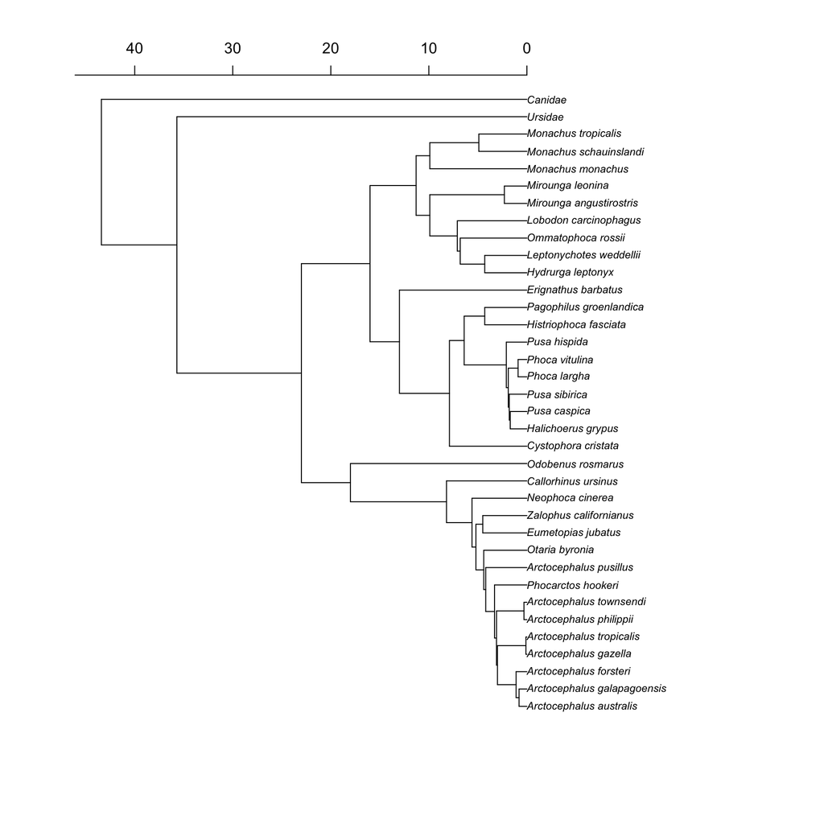

Fig 1: Phylogenetic tree of the Pinnipeds with axis in millions of years based on data from (Hidgon, et. al., 2007).

This tree shows the 33 extant species of pinnipeds, as well as the recently extinct Caribbean Monk Seal (*Monachus tropicalis*). Since the study this tree is based on was published the Caribbean Monk Seal and it’s sister taxa, the Hawaiian Monk seal have been reclassified into their own genus *Neomonachus* based on analysis of cytochrome B sequences (Scheel, et. al., 2014).

#### Analysis

###### Tree Topology:

```r
is.ultrametric(tree)
```

```
## [1] TRUE
```

```r
is.binary(tree)
```

```
## [1] TRUE
```

The tree being ultrametric was expected as this is a tree of all extant pinnipeds and both of the outgroups used are also clades that still exist today so all of the branches should continue until the present day, and therefore be equidistant from the root.

Although it mathes the observed branching pattern of the tree it was slightly unexpected that the tree was found to be bifurcating. This is because this suggeststhe tree contains no polytomies. This is interesting however as it has been suggested that polytomies could exist both at the basal end of the tribe *Phocini* (one of three tribes that make up the *Phocinae* subfamily of earless/true seals) and potentially within the genus *Pusa* (Hidgon, et. al., 2007).

It is also important to check these as some of the functions used to analyse tree metrics assume that trees are ultrametric and bifurcating.

###### Phylogenetic diversity:

```r
sum(tree$edge.length)
```

```
## [1] 319.8
```

As the branch lengths in this tree are based on divergence dates in millions of years the total sum of branch lengths can be used to indicate the total amount of evolutionary history contained within the tree. This shows that this tree contains 319.8 years of evolutionary history, however this includes the *Canidae* and *Ursidae* out groups.

From this point forward the tree containing no outgroups will be used so that analyses are concerning solely the pinnipeds.

```r
phylo_div
```

```
## [1] 220.3
```

Running this excluding outgroups, shows that from the last common pinniped ancestor of living pinnipeds there are 220.3 million years of evolutionary history are preserved within the group.

###### Tree Imbalance:

```r
imbalance
```

```
## [1] 0.6789046
```

###### Speciation Rate:

Speciation rate can be calculated by fitting the yule process to a tree which then allows you to calculate the instantaneous speciation rate λ. This is multiplied by the number of species to calculate the total speciation rate (Crawford & Suchard, 2013)

```r
speciation_rate
```

```
## [1] 4.93872
```

## Summary of Metrics

#### Table:

Fig 2: Table summarising various metrics associated with the phylogenetic tree.

|  | Phylogenetic Diversity | Imbalance | Speciation Rate |
| --- | --- | --- | --- |
| Values | 220.3 | 0.6789046 | 4.93872 |

## Evolutionary Diversity per Tip

#### Plotting Bar Chart:

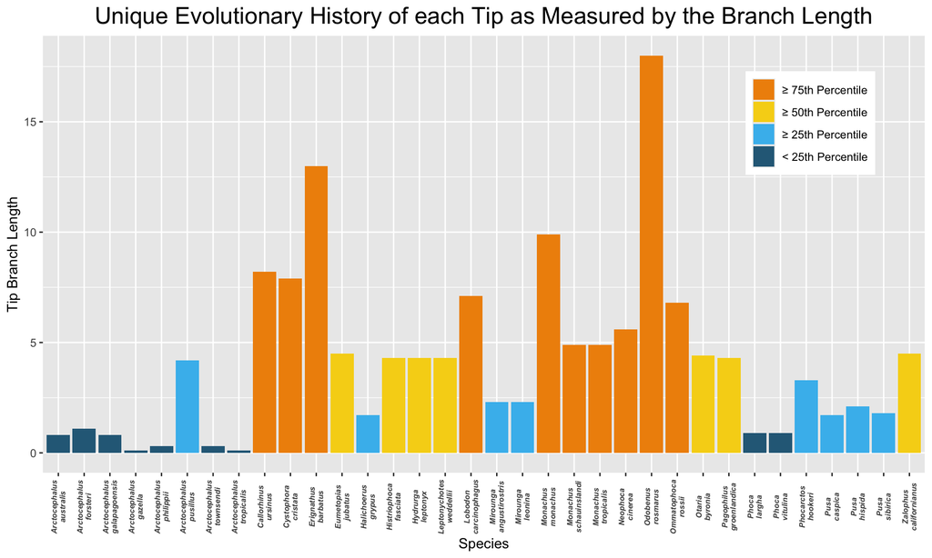

Fig 3: Bar Chart showing the Evolutionary Diversity of each tip

## Modelling the Effect of Random Extinctions

###### Models:

The code below simulates 100 random extinctions of a single species.

```r
rmv_1_sp<- matrix(nrow = 100)

for(i in 1:100) {
tree_trimmed1 <- drop.tip(tree, tree$tip.label[sample(1:34,1)])
rmv_1_sp[[i]]<-(sum(tree_trimmed1$edge.length))
}
```

#### Plotting Graph:

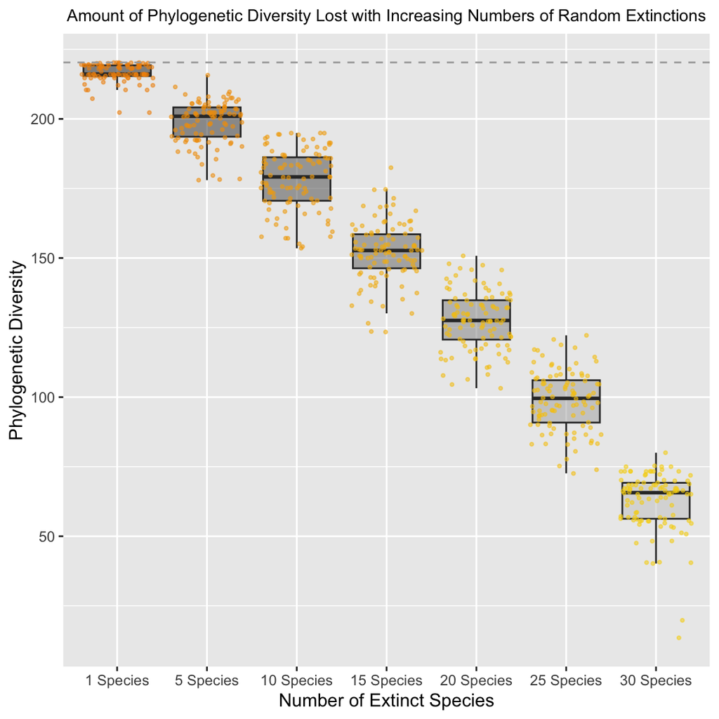

Fig 4: A box plot showing mean loss and variation in loss of phylogenetic diversity as more species randomly go exting. Dashed line represents diversity with no extinctions

As expected this graph shows that the more species which go extinct the more phylogenetic diversity is lost. The general pattern is a step-wise decrease, every five additional extinction causing another loss of around 25 million years of phylogenetic diversity. This suggests that rate of diversity loss per species is constant and could potentially be predicted by fitting it to a linear model. However especially at intermediate levels of extinction there is a lot of variability in the exact amount of diversity lost. Indicating that the impact of extinctions on diversity is dependent on which species is actually going extinct, and therefore the different pinniped species do not equally contribute to diversity.

## Tip Diversification Rate

###### Calculating Tip Diversification:

Because the tree is ultrametric all of the tips are the same length from the tree base.

```r
total_branch_length
```

```
## [1] 23
```

23 is the total branch length from node to tip for all tips, since the tree is ultrametric this means that the last common ancestor of all extant pinnipeds existed at least 23 MYA.

In order to track the diversification rate across pinniped ancestors each species was grouped into either “High” or “Low” depending on whether their tip diversification rate was above or below the median.

#### Map Diversification Rate onto Phylogeny:

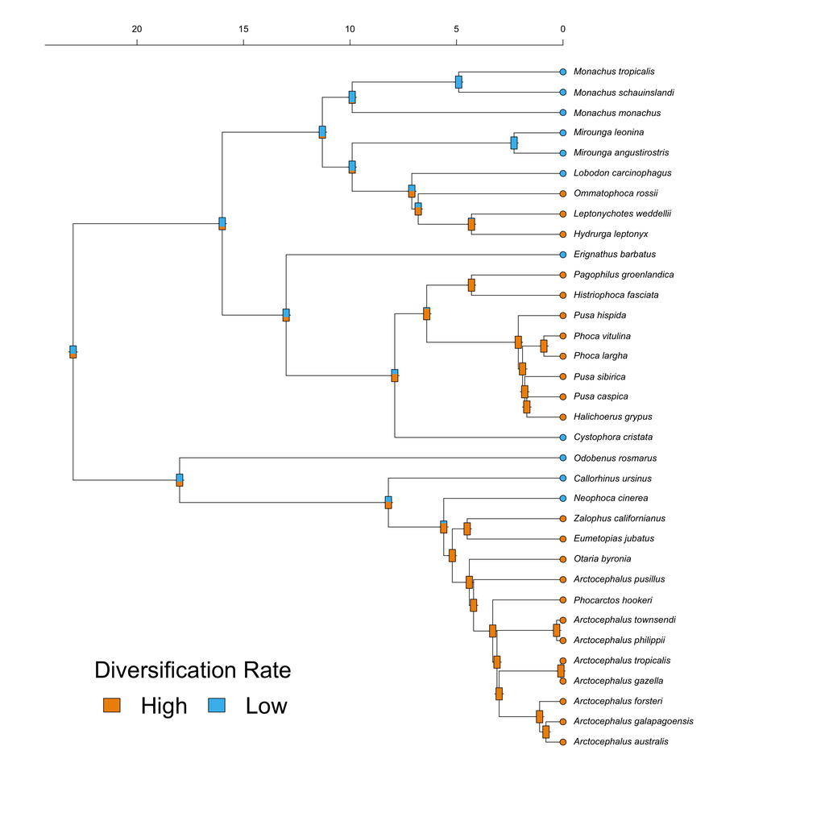

Fig 4: Phylogenetic tree with tip diversification rates and the probability this is the same as your ancestor mapped onto it

This graph suggests that the ancestral state of the pinniped clade is to diversify at a slow rate, with rapid diverisifications happening more recently, mostly within the last 8 million years. In fact the majority of extant pinnipeds were identified as having a high diversification rate. Overall the extant Phocids appear to have undergone less rapid diversification than the Otariids with the majority of slow diversifiers being found within them. This is mostly due to slow tip diversification rate within the *Monachinae*.

## Bibliography

(Higdon, et al., 2007) doi: https://doi.org/10.1186/1471-2148-7-216

(McTravish, et al., 2015) doi: https://doi.org/10.1093/bioinformatics/btv276

(Park, et al., 2024) doi: https://doi.org/10.1093/evolut/qpae061

(Crawford & Suchard, 2013) doi: https://doi.org/10.1093/sysbio/syt010

(Scheel, et al., 2014) doi: https://doi.org/10.3897/zookeys.409.6244